# *An Overview of the Tate Art Museum*

Jena Baxter - "jbaxter1244@floridapoly.edu"

# Introduction

The Tate Art Museum, located in London, is home to the national collection of 16th century of British art and is its national modern art collection, being one of the largest museums of contemporary and modern art in the country. Yet, just what are the specialties of their art exhibits?

- How varied are the mediums of the pieces?
- What is their largest piece?
- Where even are the exhibited artists from?

With this project, it aims to observe a new look at an art museum and delve closer to the more minute pieces of the artwork.

# Loading the Tidyverse and CSV Files

As a preface, both read_csv files are needed. The *artwork.csv* includes the specifics of the artwork, and the *artist.csv* the details of the artist.

```r
library(tidyverse)
library(dplyr)
library(ggplot2)
library(knitr)
artwork <- readr::read_csv('https://raw.githubusercontent.com/rfordatascience/tidytuesday/master/data/2021/2021-01-12/artwork.csv')
artists <- readr::read_csv("https://github.com/tategallery/collection/raw/master/artist_data.csv")
```

```r
artwork
```

| id | accession_number | artist | artistRole | artistId | title | dateText | medium | creditLine | year | acquisitionYear | dimensions | width | height | depth | units | inscription | thumbnailCopyright | thumbnailUrl | url |
| --- | --- | --- | --- | --- | --- | --- | --- | --- | --- | --- | --- | --- | --- | --- | --- | --- | --- | --- | --- |
| 1035 | A00001 | Blake, Robert | artist | 38 | A Figure Bowing before a Seated Old Man with his Arm Outstretched in Benediction. Verso: Indecipherable Sketch | date not known | Watercolour, ink, chalk and graphite on paper. Verso: graphite on paper | Presented by Mrs John Richmond 1922 | NA | 1922 | support: 394 x 419 mm | 394 | 419 | NA | mm | NA | NA | http://www.tate.org.uk/art/images/work/A/A00/A00001_8.jpg | http://www.tate.org.uk/art/artworks/blake-a-figure-bowing-before-a-seated-old-man-with-his-arm-outstretched-in-benediction-a00001 |
| 1036 | A00002 | Blake, Robert | artist | 38 | Two Drawings of Frightened Figures, Probably for ‘The Approach of Doom’ | date not known | Graphite on paper | Presented by Mrs John Richmond 1922 | NA | 1922 | support: 311 x 213 mm | 311 | 213 | NA | mm | NA | NA | http://www.tate.org.uk/art/images/work/A/A00/A00002_8.jpg | http://www.tate.org.uk/art/artworks/blake-two-drawings-of-frightened-figures-probably-for-the-approach-of-doom-a00002 |
| 1037 | A00003 | Blake, Robert | artist | 38 | The Preaching of Warning. Verso: An Old Man Enthroned Between Two Groups of Figures, by ?William Blake | ?c.1785 | Graphite on paper. Verso: graphite on paper | Presented by Mrs John Richmond 1922 | 1785 | 1922 | support: 343 x 467 mm | 343 | 467 | NA | mm | NA | NA | http://www.tate.org.uk/art/images/work/A/A00/A00003_8.jpg | http://www.tate.org.uk/art/artworks/blake-the-preaching-of-warning-verso-an-old-man-enthroned-between-two-groups-of-figures-by-a00003 |
| 1038 | A00004 | Blake, Robert | artist | 38 | Six Drawings of Figures with Outstretched Arms | date not known | Graphite on paper | Presented by Mrs John Richmond 1922 | NA | 1922 | support: 318 x 394 mm | 318 | 394 | NA | mm | NA | NA | http://www.tate.org.uk/art/images/work/A/A00/A00004_8.jpg | http://www.tate.org.uk/art/artworks/blake-six-drawings-of-figures-with-outstretched-arms-a00004 |
| 1039 | A00005 | Blake, William | artist | 39 | The Circle of the Lustful: Francesca da Rimini (‘The Whirlwind of Lovers’) | 1826–7, reprinted 1892 | Line engraving on paper | Purchased with the assistance of a special grant from the National Gallery and donations from the Art Fund, Lord Duveen and others, and presented through the the Art Fund 1919 | 1826 | 1919 | image: 243 x 335 mm | 243 | 335 | NA | mm | NA | NA | http://www.tate.org.uk/art/images/work/A/A00/A00005_8.jpg | http://www.tate.org.uk/art/artworks/blake-the-circle-of-the-lustful-francesca-da-rimini-the-whirlwind-of-lovers-a00005 |
| 1040 | A00006 | Blake, William | artist | 39 | Ciampolo the Barrator Tormented by the Devils | 1826–7, reprinted 1892 | Line engraving on paper | Purchased with the assistance of a special grant from the National Gallery and donations from the Art Fund, Lord Duveen and others, and presented through the the Art Fund 1919 | 1826 | 1919 | image: 240 x 338 mm | 240 | 338 | NA | mm | NA | NA | http://www.tate.org.uk/art/images/work/A/A00/A00006_8.jpg | http://www.tate.org.uk/art/artworks/blake-ciampolo-the-barrator-tormented-by-the-devils-a00006 |
| 1041 | A00007 | Blake, William | artist | 39 | The Baffled Devils Fighting | 1826–7, reprinted 1892 | Line engraving on paper | Purchased with the assistance of a special grant from the National Gallery and donations from the Art Fund, Lord Duveen and others, and presented through the the Art Fund 1919 | 1826 | 1919 | image: 242 x 334 mm | 242 | 334 | NA | mm | NA | NA | http://www.tate.org.uk/art/images/work/A/A00/A00007_8.jpg | http://www.tate.org.uk/art/artworks/blake-the-baffled-devils-fighting-a00007 |
| 1042 | A00008 | Blake, William | artist | 39 | The Six-Footed Serpent Attacking Agnolo Brunelleschi | 1826–7, reprinted 1892 | Line engraving on paper | Purchased with the assistance of a special grant from the National Gallery and donations from the Art Fund, Lord Duveen and others, and presented through the the Art Fund 1919 | 1826 | 1919 | image: 246 x 340 mm | 246 | 340 | NA | mm | NA | NA | http://www.tate.org.uk/art/images/work/A/A00/A00008_8.jpg | http://www.tate.org.uk/art/artworks/blake-the-six-footed-serpent-attacking-agnolo-brunelleschi-a00008 |
| 1043 | A00009 | Blake, William | artist | 39 | The Serpent Attacking Buoso Donati | 1826–7, reprinted 1892 | Line engraving on paper | Purchased with the assistance of a special grant from the National Gallery and donations from the Art Fund, Lord Duveen and others, and presented through the the Art Fund 1919 | 1826 | 1919 | image: 241 x 335 mm | 241 | 335 | NA | mm | NA | NA | http://www.tate.org.uk/art/images/work/A/A00/A00009_8.jpg | http://www.tate.org.uk/art/artworks/blake-the-serpent-attacking-buoso-donati-a00009 |
| 1044 | A00010 | Blake, William | artist | 39 | The Pit of Disease: The Falsifiers | 1826–7, reprinted 1892 | Line engraving on paper | Purchased with the assistance of a special grant from the National Gallery and donations from the Art Fund, Lord Duveen and others, and presented through the the Art Fund 1919 | 1826 | 1919 | image: 243 x 340 mm | 243 | 340 | NA | mm | NA | NA | http://www.tate.org.uk/art/images/work/A/A00/A00010_8.jpg | http://www.tate.org.uk/art/artworks/blake-the-pit-of-disease-the-falsifiers-a00010 |

[output cut: 990 more lines]

```r
artists
```

| id | name | gender | dates | yearOfBirth | yearOfDeath | placeOfBirth | placeOfDeath | url |
| --- | --- | --- | --- | --- | --- | --- | --- | --- |
| 10093 | Abakanowicz, Magdalena | Female | born 1930 | 1930 | NA | Polska | NA | http://www.tate.org.uk/art/artists/magdalena-abakanowicz-10093 |
| 0 | Abbey, Edwin Austin | Male | 1852–1911 | 1852 | 1911 | Philadelphia, United States | London, United Kingdom | http://www.tate.org.uk/art/artists/edwin-austin-abbey-0 |
| 2756 | Abbott, Berenice | Female | 1898–1991 | 1898 | 1991 | Springfield, United States | Monson, United States | http://www.tate.org.uk/art/artists/berenice-abbott-2756 |
| 1 | Abbott, Lemuel Francis | Male | 1760–1803 | 1760 | 1803 | Leicestershire, United Kingdom | London, United Kingdom | http://www.tate.org.uk/art/artists/lemuel-francis-abbott-1 |
| 622 | Abrahams, Ivor | Male | born 1935 | 1935 | NA | Wigan, United Kingdom | NA | http://www.tate.org.uk/art/artists/ivor-abrahams-622 |
| 2606 | Absalon | Male | 1964–1993 | 1964 | 1993 | Tel Aviv-Yafo, Yisra'el | Paris, France | http://www.tate.org.uk/art/artists/absalon-2606 |
| 9550 | Abts, Tomma | Female | born 1967 | 1967 | NA | Kiel, Deutschland | NA | http://www.tate.org.uk/art/artists/tomma-abts-9550 |
| 623 | Acconci, Vito | Male | born 1940 | 1940 | NA | New York, United States | NA | http://www.tate.org.uk/art/artists/vito-acconci-623 |
| 624 | Ackling, Roger | Male | 1947–2014 | 1947 | 2014 | Isleworth, United Kingdom | NA | http://www.tate.org.uk/art/artists/roger-ackling-624 |
| 625 | Ackroyd, Norman | Male | born 1938 | 1938 | NA | Leeds, United Kingdom | NA | http://www.tate.org.uk/art/artists/norman-ackroyd-625 |

[output cut: 990 more lines]

## Era Organization

As art pieces are denoted typically by their stylistic choices, sorting the pieces by art era allows any reader to easily see what pieces originated during what time. While some of the years of creation are unknown and labeled as such, the rest of the vector gives a broad look at the showcased time periods. Looking through the *artwork* set shows that there’s loads of unknown years for some pieces! However, looking through the *mediums* and at the actual *urls* of the pieces themselves on the *artwork* dataset shows that many may have simply been sketches or smaller works. Thus, they can’t be as accurately dated as pieces that were meant to be seen by the public.

These classifications also may be a mix of other eras as it was simply easier to classify some in groups rather than alone. In order, the eras would be *Mannerism*, *Baroque*, *Rococo*, *Classicism*, *Romanticism*, *Realism*, *Impressionism*, *Symbolism*, *Art Nouveau*, *Expressionism*, *Surrealism* (which is an overarching name to *Cubism*, *Futurism*, and *Dadaism*), *Pop Art*, and finally our current art era, *Modernism*.

```r
#function that sorts artists by era
art_eras <- artwork %>%
  mutate(
    era = case_when(
          year %in% c(1520:1599) ~ "mannerism",
          year %in% c(1600:1780) ~ "baroque_rococo",
          year %in% c(1781:1849) ~ "class_romance_real",
          year %in% c(1850:1889) ~ "impressionism",
          year %in% c(1890:1905) ~ "symbol_nouveau_express",
          year %in% c(1906:1924) ~ "surrealism",
          year %in% c(1925:1954) ~ "abstract",
          year %in% c(1955:1969) ~ "popart",
          year %in% c(1970:2020) ~ "modern",
          TRUE ~ "unknown"
    ) )
art_eras
```

| id | accession_number | artist | artistRole | artistId | title | dateText | medium | creditLine | year | acquisitionYear | dimensions | width | height | depth | units | inscription | thumbnailCopyright | thumbnailUrl | url | era |
| --- | --- | --- | --- | --- | --- | --- | --- | --- | --- | --- | --- | --- | --- | --- | --- | --- | --- | --- | --- | --- |
| 1035 | A00001 | Blake, Robert | artist | 38 | A Figure Bowing before a Seated Old Man with his Arm Outstretched in Benediction. Verso: Indecipherable Sketch | date not known | Watercolour, ink, chalk and graphite on paper. Verso: graphite on paper | Presented by Mrs John Richmond 1922 | NA | 1922 | support: 394 x 419 mm | 394 | 419 | NA | mm | NA | NA | http://www.tate.org.uk/art/images/work/A/A00/A00001_8.jpg | http://www.tate.org.uk/art/artworks/blake-a-figure-bowing-before-a-seated-old-man-with-his-arm-outstretched-in-benediction-a00001 | unknown |
| 1036 | A00002 | Blake, Robert | artist | 38 | Two Drawings of Frightened Figures, Probably for ‘The Approach of Doom’ | date not known | Graphite on paper | Presented by Mrs John Richmond 1922 | NA | 1922 | support: 311 x 213 mm | 311 | 213 | NA | mm | NA | NA | http://www.tate.org.uk/art/images/work/A/A00/A00002_8.jpg | http://www.tate.org.uk/art/artworks/blake-two-drawings-of-frightened-figures-probably-for-the-approach-of-doom-a00002 | unknown |
| 1037 | A00003 | Blake, Robert | artist | 38 | The Preaching of Warning. Verso: An Old Man Enthroned Between Two Groups of Figures, by ?William Blake | ?c.1785 | Graphite on paper. Verso: graphite on paper | Presented by Mrs John Richmond 1922 | 1785 | 1922 | support: 343 x 467 mm | 343 | 467 | NA | mm | NA | NA | http://www.tate.org.uk/art/images/work/A/A00/A00003_8.jpg | http://www.tate.org.uk/art/artworks/blake-the-preaching-of-warning-verso-an-old-man-enthroned-between-two-groups-of-figures-by-a00003 | class_romance_real |
| 1038 | A00004 | Blake, Robert | artist | 38 | Six Drawings of Figures with Outstretched Arms | date not known | Graphite on paper | Presented by Mrs John Richmond 1922 | NA | 1922 | support: 318 x 394 mm | 318 | 394 | NA | mm | NA | NA | http://www.tate.org.uk/art/images/work/A/A00/A00004_8.jpg | http://www.tate.org.uk/art/artworks/blake-six-drawings-of-figures-with-outstretched-arms-a00004 | unknown |
| 1039 | A00005 | Blake, William | artist | 39 | The Circle of the Lustful: Francesca da Rimini (‘The Whirlwind of Lovers’) | 1826–7, reprinted 1892 | Line engraving on paper | Purchased with the assistance of a special grant from the National Gallery and donations from the Art Fund, Lord Duveen and others, and presented through the the Art Fund 1919 | 1826 | 1919 | image: 243 x 335 mm | 243 | 335 | NA | mm | NA | NA | http://www.tate.org.uk/art/images/work/A/A00/A00005_8.jpg | http://www.tate.org.uk/art/artworks/blake-the-circle-of-the-lustful-francesca-da-rimini-the-whirlwind-of-lovers-a00005 | class_romance_real |
| 1040 | A00006 | Blake, William | artist | 39 | Ciampolo the Barrator Tormented by the Devils | 1826–7, reprinted 1892 | Line engraving on paper | Purchased with the assistance of a special grant from the National Gallery and donations from the Art Fund, Lord Duveen and others, and presented through the the Art Fund 1919 | 1826 | 1919 | image: 240 x 338 mm | 240 | 338 | NA | mm | NA | NA | http://www.tate.org.uk/art/images/work/A/A00/A00006_8.jpg | http://www.tate.org.uk/art/artworks/blake-ciampolo-the-barrator-tormented-by-the-devils-a00006 | class_romance_real |
| 1041 | A00007 | Blake, William | artist | 39 | The Baffled Devils Fighting | 1826–7, reprinted 1892 | Line engraving on paper | Purchased with the assistance of a special grant from the National Gallery and donations from the Art Fund, Lord Duveen and others, and presented through the the Art Fund 1919 | 1826 | 1919 | image: 242 x 334 mm | 242 | 334 | NA | mm | NA | NA | http://www.tate.org.uk/art/images/work/A/A00/A00007_8.jpg | http://www.tate.org.uk/art/artworks/blake-the-baffled-devils-fighting-a00007 | class_romance_real |
| 1042 | A00008 | Blake, William | artist | 39 | The Six-Footed Serpent Attacking Agnolo Brunelleschi | 1826–7, reprinted 1892 | Line engraving on paper | Purchased with the assistance of a special grant from the National Gallery and donations from the Art Fund, Lord Duveen and others, and presented through the the Art Fund 1919 | 1826 | 1919 | image: 246 x 340 mm | 246 | 340 | NA | mm | NA | NA | http://www.tate.org.uk/art/images/work/A/A00/A00008_8.jpg | http://www.tate.org.uk/art/artworks/blake-the-six-footed-serpent-attacking-agnolo-brunelleschi-a00008 | class_romance_real |
| 1043 | A00009 | Blake, William | artist | 39 | The Serpent Attacking Buoso Donati | 1826–7, reprinted 1892 | Line engraving on paper | Purchased with the assistance of a special grant from the National Gallery and donations from the Art Fund, Lord Duveen and others, and presented through the the Art Fund 1919 | 1826 | 1919 | image: 241 x 335 mm | 241 | 335 | NA | mm | NA | NA | http://www.tate.org.uk/art/images/work/A/A00/A00009_8.jpg | http://www.tate.org.uk/art/artworks/blake-the-serpent-attacking-buoso-donati-a00009 | class_romance_real |
| 1044 | A00010 | Blake, William | artist | 39 | The Pit of Disease: The Falsifiers | 1826–7, reprinted 1892 | Line engraving on paper | Purchased with the assistance of a special grant from the National Gallery and donations from the Art Fund, Lord Duveen and others, and presented through the the Art Fund 1919 | 1826 | 1919 | image: 243 x 340 mm | 243 | 340 | NA | mm | NA | NA | http://www.tate.org.uk/art/images/work/A/A00/A00010_8.jpg | http://www.tate.org.uk/art/artworks/blake-the-pit-of-disease-the-falsifiers-a00010 | class_romance_real |

[output cut: 990 more lines]

For example, what if you wanted to see the art made during the *surrealism* era?

```r
filter(art_eras, era == "surrealism")
```

| id | accession_number | artist | artistRole | artistId | title | dateText | medium | creditLine | year | acquisitionYear | dimensions | width | height | depth | units | inscription | thumbnailCopyright | thumbnailUrl | url | era |
| --- | --- | --- | --- | --- | --- | --- | --- | --- | --- | --- | --- | --- | --- | --- | --- | --- | --- | --- | --- | --- |
| 850 | A01038 | Beerbohm, Sir Max | artist | 722 | D.G. Rossetti Precociously Manifesting ... that Queer Indifference to Politics ... | 1916–7 | Graphite and watercolour on paper | Bequeathed by Sir Hugh Walpole 1941 | 1916 | 1941 | support: 273 x 419 mm | 273.0 | 419.0 | NA | mm | NA | NA | http://www.tate.org.uk/art/images/work/A/A01/A01038_8.jpg | http://www.tate.org.uk/art/artworks/beerbohm-dg-rossetti-precociously-manifesting-that-queer-indifference-to-politics-a01038 | surrealism |
| 851 | A01039 | Beerbohm, Sir Max | artist | 722 | British Stock and Alien Inspiration, 1849 | 1917 | Graphite and watercolour on paper | Bequeathed by Sir Hugh Walpole 1941 | 1917 | 1941 | support: 298 x 419 mm | 298.0 | 419.0 | NA | mm | date inscribed | NA | http://www.tate.org.uk/art/images/work/A/A01/A01039_8.jpg | http://www.tate.org.uk/art/artworks/beerbohm-british-stock-and-alien-inspiration-1849-a01039 | surrealism |
| 852 | A01040 | Beerbohm, Sir Max | artist | 722 | Rossetti’s Courtship | 1916 | Graphite and watercolour on paper | Bequeathed by Sir Hugh Walpole 1941 | 1916 | 1941 | support: 324 x 210 mm | 324.0 | 210.0 | NA | mm | date inscribed | NA | http://www.tate.org.uk/art/images/work/A/A01/A01040_8.jpg | http://www.tate.org.uk/art/artworks/beerbohm-rossettis-courtship-a01040 | surrealism |
| 853 | A01041 | Beerbohm, Sir Max | artist | 722 | The Sole Remark Likely to Have Been Made by Benjamin Jowett about the Mural Paintings at the Oxford Union | 1916 | Graphite and watercolour on paper | Bequeathed by Sir Hugh Walpole 1941 | 1916 | 1941 | support: 451 x 298 mm | 451.0 | 298.0 | NA | mm | date inscribed | NA | http://www.tate.org.uk/art/images/work/A/A01/A01041_8.jpg | http://www.tate.org.uk/art/artworks/beerbohm-the-sole-remark-likely-to-have-been-made-by-benjamin-jowett-about-the-mural-a01041 | surrealism |
| 854 | A01042 | Beerbohm, Sir Max | artist | 722 | Miss Cornforth: ‘Oh, very pleased to meet Mr Ruskin, I’m sure’ | 1916 | Graphite and watercolour on paper | Bequeathed by Sir Hugh Walpole 1941 | 1916 | 1941 | support: 330 x 248 mm | 330.0 | 248.0 | NA | mm | date inscribed | NA | http://www.tate.org.uk/art/images/work/A/A01/A01042_8.jpg | http://www.tate.org.uk/art/artworks/beerbohm-miss-cornforth-oh-very-pleased-to-meet-mr-ruskin-im-sure-a01042 | surrealism |
| 855 | A01043 | Beerbohm, Sir Max | artist | 722 | Ford Madox Brown being Patronized by Holman Hunt | 1916 | Graphite and watercolour on paper | Bequeathed by Sir Hugh Walpole 1941 | 1916 | 1941 | support: 362 x 397 mm | 362.0 | 397.0 | NA | mm | date inscribed | NA | http://www.tate.org.uk/art/images/work/A/A01/A01043_8.jpg | http://www.tate.org.uk/art/artworks/beerbohm-ford-madox-brown-being-patronized-by-holman-hunt-a01043 | surrealism |
| 856 | A01044 | Beerbohm, Sir Max | artist | 722 | A Momentary Vision that Once Befell Young Millais | 1916 | Graphite and watercolour on paper | Bequeathed by Sir Hugh Walpole 1941 | 1916 | 1941 | support: 324 x 432 mm | 324.0 | 432.0 | NA | mm | date inscribed | NA | http://www.tate.org.uk/art/images/work/A/A01/A01044_8.jpg | http://www.tate.org.uk/art/artworks/beerbohm-a-momentary-vision-that-once-befell-young-millais-a01044 | surrealism |
| 857 | A01045 | Beerbohm, Sir Max | artist | 722 | Spring Cottage, Hampstead, 1860 | 1917 | Graphite and watercolour on paper | Bequeathed by Sir Hugh Walpole 1941 | 1917 | 1941 | support: 324 x 432 mm | 324.0 | 432.0 | NA | mm | date inscribed | NA | http://www.tate.org.uk/art/images/work/A/A01/A01045_8.jpg | http://www.tate.org.uk/art/artworks/beerbohm-spring-cottage-hampstead-1860-a01045 | surrealism |
| 858 | A01046 | Beerbohm, Sir Max | artist | 722 | Woolner at Farringford, 1857 | 1917 | Graphite and watercolour on paper | Bequeathed by Sir Hugh Walpole 1941 | 1917 | 1941 | support: 330 x 260 mm | 330.0 | 260.0 | NA | mm | date inscribed | NA | http://www.tate.org.uk/art/images/work/A/A01/A01046_8.jpg | http://www.tate.org.uk/art/artworks/beerbohm-woolner-at-farringford-1857-a01046 | surrealism |
| 859 | A01047 | Beerbohm, Sir Max | artist | 722 | Blue China | 1916 | Graphite and watercolour on paper | Bequeathed by Sir Hugh Walpole 1941 | 1916 | 1941 | support: 337 x 273 mm | 337.0 | 273.0 | NA | mm | date inscribed | NA | http://www.tate.org.uk/art/images/work/A/A01/A01047_8.jpg | http://www.tate.org.uk/art/artworks/beerbohm-blue-china-a01047 | surrealism |

[output cut: 990 more lines]

This prompts a list of artists and their respective work from the years 1906 to 1924 with the “era” category of surrealism from the *artwork.csv*.

Doing this with the *artists.csv* would produce a similar result, but is ultimately made moot due to the name of the artists already being displayed.

# Prior Exploration

Before answering any of the proposed questions, a brief overview of both datasets is necessary:

```r
summary(artists)
```

```
       id              name              gender             dates            yearOfBirth    yearOfDeath
 Min.   :    0.0   Length:3532        Length:3532        Length:3532        Min.   :1497   Min.   :1543
 1st Qu.:  885.8   Class :character   Class :character   Class :character   1st Qu.:1855   1st Qu.:1876
 Median : 1772.5   Mode  :character   Mode  :character   Mode  :character   Median :1910   Median :1944
 Mean   : 3330.3                                                            Mean   :1887   Mean   :1921
 3rd Qu.: 2676.2                                                            3rd Qu.:1941   3rd Qu.:1983
 Max.   :18896.0                                                            Max.   :2004   Max.   :2014
                                                                            NA's   :60     NA's   :1304
 placeOfBirth       placeOfDeath           url
 Length:3532        Length:3532        Length:3532
 Class :character   Class :character   Class :character
 Mode  :character   Mode  :character   Mode  :character
```

```r
summary(artwork)
```

```
       id         accession_number      artist           artistRole           artistId        title
 Min.   :     3   Length:69201       Length:69201       Length:69201       Min.   :    0   Length:69201
 1st Qu.: 19096   Class :character   Class :character   Class :character   1st Qu.:  558   Class :character
 Median : 37339   Mode  :character   Mode  :character   Mode  :character   Median :  558   Mode  :character
 Mean   : 39148                                                            Mean   : 1201
 3rd Qu.: 54712                                                            3rd Qu.: 1137
 Max.   :129068                                                            Max.   :19232

   dateText            medium           creditLine             year      acquisitionYear  dimensions
 Length:69201       Length:69201       Length:69201       Min.   :1545   Min.   :1823    Length:69201
 Class :character   Class :character   Class :character   1st Qu.:1817   1st Qu.:1856    Class :character
 Mode  :character   Mode  :character   Mode  :character   Median :1831   Median :1856    Mode  :character
                                                          Mean   :1867   Mean   :1911
                                                          3rd Qu.:1953   3rd Qu.:1982
                                                          Max.   :2012   Max.   :2013
                                                          NA's   :5397   NA's   :45
     width             height            depth             units           inscription        thumbnailCopyright
 Min.   :    3.0   Min.   :    6.0   Min.   :    1.00   Length:69201       Length:69201       Mode:logical
 1st Qu.:  118.0   1st Qu.:  117.0   1st Qu.:   48.25   Class :character   Class :character   NA's:69201
 Median :  175.0   Median :  190.0   Median :  190.00   Mode  :character   Mode  :character
 Mean   :  323.5   Mean   :  346.4   Mean   :  479.20
 3rd Qu.:  345.0   3rd Qu.:  359.0   3rd Qu.:  450.00
 Max.   :11960.0   Max.   :37500.0   Max.   :18290.00
 NA's   :3367      NA's   :3342      NA's   :66687
 thumbnailUrl           url
 Length:69201       Length:69201
 Class :character   Class :character
 Mode  :character   Mode  :character
```

## Data Exploration

As both datasets are incredibly large, organizing it by a much smaller margin makes the data easier to handle. Broader visualizations allow a simple overview of what we’re handling.

### Univariate Analysis

Below is a few basic visuals of the datasets. Specializing and focusing on the broader variables will make combining them for more complex answers later on easier.

#### Art Periods

Through a brief overview of one of the many variables, we can check to see when exactly most pieces come from - era-wise.

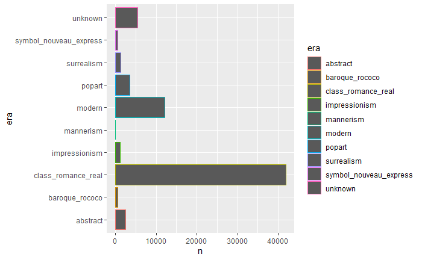

```r
filter(count(art_eras, era)) %>%
  ggplot() +
  geom_bar(aes(x = n, y = era, color = era), stat = 'identity')
```

The bar graph above shows that over 40,000 of our pieces were made during *Classicism*, *Romanticism*, or *Realism*! Being as the museum is in Europe, it’s understandable that most of their pieces come from art periods of high prominence in an older Europe.

#### Genders

As another variable includes gender, I expect to see a prominence of male artists to female due to the age of most of the art as well.

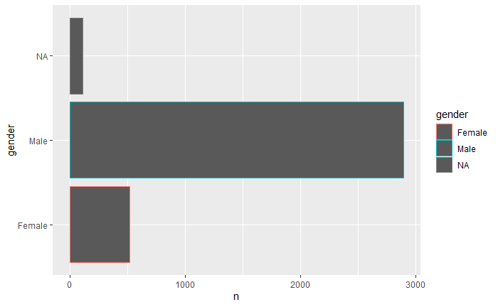

```r
filter(count(artists, gender)) %>%
  ggplot() +
  geom_histogram(aes(x = n, y = gender, color = gender), stat = 'identity')
```

And the assumption is entirely correct. Just under 3,000 artists are male, while just over 500 are female. However, we also are left with a very small amount of unknown artists more than likely due to a lack of updated data on the set’s end or a genuine lack of knowledge for the artist.

### Bivariate Analysis

Since many variables in this set include long names, I’ve opted to leave those variables for other visualizations and instead pose a different look at a combination of data

#### Deaths

We can also see how many artists have died in what year with their genders. With the newfound knowledge that most of our pieces are a few decades or centuries old we can assume that most have passed by now and will be male.

```
Warning: Removed 1304 rows containing missing values (geom_point).
```

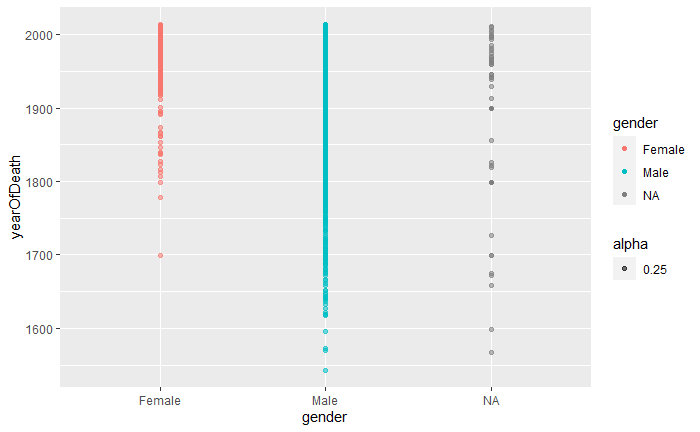

```r
artists %>%
  ggplot() +
  geom_point(aes(x = gender, y = yearOfDeath, color = gender, alpha = 0.25))
```

And the assumption is correct. The majority of artists have passed and were almost always male, the removed values the warning mentions referring to those who are living.

And seen below are artists who’ve been the more recent of the deaths. We can also filter those recent deaths by gender as well and see our already small amount of female artists is even shorter. I can imagine if the list were of those who were living, it’d be minuscule.

```r
filter(artists, yearOfDeath > 2000) %>%
  filter(gender == "Female")
```

| id | name | gender | dates | yearOfBirth | yearOfDeath | placeOfBirth | placeOfDeath | url |
| --- | --- | --- | --- | --- | --- | --- | --- | --- |
| 697 | Barns-Graham, Wilhelmina | Female | 1912–2004 | 1912 | 2004 | Saint Andrews, United Kingdom | NA | http://www.tate.org.uk/art/artists/wilhelmina-barns-graham-697 |
| 10983 | Beban, Breda | Female | 1952–2012 | 1952 | 2012 | Novi Sad, Jugoslavija | NA | http://www.tate.org.uk/art/artists/breda-beban-10983 |
| 770 | Blow, Sandra | Female | 1925–2006 | 1925 | 2006 | London, United Kingdom | NA | http://www.tate.org.uk/art/artists/sandra-blow-770 |
| 2351 | Bourgeois, Louise | Female | 1911–2010 | 1911 | 2010 | Paris, France | New York, United States | http://www.tate.org.uk/art/artists/louise-bourgeois-2351 |
| 8804 | Braden, Norah | Female | 1901–2001 | 1901 | 2001 | Margate, United Kingdom | Chichester, United Kingdom | http://www.tate.org.uk/art/artists/norah-braden-8804 |
| 847 | Caiserman-Roth, Ghitta | Female | 1923–2005 | 1923 | 2005 | Québec, Canada | Montréal | http://www.tate.org.uk/art/artists/ghitta-caiserman-roth-847 |
| 12113 | Cantor, Ellen | Female | 1963 – 2013 | 1963 | 2013 | Detroit, United States | NA | http://www.tate.org.uk/art/artists/ellen-cantor-12113 |
| 861 | Carline, Nancy | Female | 1909–2004 | 1909 | 2004 | London, United Kingdom | NA | http://www.tate.org.uk/art/artists/nancy-carline-861 |
| 7615 | Carrington, Leonora | Female | 1917–2011 | 1917 | 2011 | Lancashire, United Kingdom | Ciudad de México, México | http://www.tate.org.uk/art/artists/leonora-carrington-7615 |
| 919 | Clinton, Margery | Female | 1931–2005 | 1931 | 2005 | NA | Dunbar, United Kingdom | http://www.tate.org.uk/art/artists/margery-clinton-919 |

[output cut: 25 more lines]

# Data Analysis

### How varied are the mediums of the pieces?

A commonality between pieces is usually a medium - what they’re actually made from. The easiest way to see the *amount* of each medium is by organizing them by such and having a count of each one. By placing them in a vector, we can also pull out the least and greatest used mediums.

```r
mediums <- artwork %>%
  group_by(medium) %>%
  count(medium)
mediums
```

| medium | n |
| --- | --- |
| 10 photo-etchings on paper | 1 |
| 10 photographs, black and white, on paper | 1 |
| 10 photographs, gelatin silver print on paper and neon lights | 1 |
| 10 photographs, gelatin silver print on paper mounted onto wooden panels | 1 |
| 10 reed boats, wood and glass | 1 |
| 10 sheets of printed paper, paper cover and detachable plastic grip | 2 |
| 10 works on paper, mud | 1 |
| 100 digital prints on paper, ink on paper and wall text | 1 |
| 100 photographs, colour, on paper mounted onto glass | 1 |
| 100 works on paper, photographs and ink | 1 |

[output cut: 990 more lines]

We can see here this list is incredibly extensive! The data shows that the museum went to extensive lengths and care to specify everything in incredible detail, as almost everything in the set is unique. Note as well that some pieces might be made of *multiple pages*, hence why the first few pages of the set include numbers.

For example, [in this image](http://www.tate.org.uk/art/images/work/T/T07/T07711_8.jpg), titled “Self-Portrait Made Using a House Converted into a Pinhole Camera”, is actually ten different photographs placed together to make one whole piece.

### What is their largest piece?

Being as varied as the art world, organizing their pieces via size is a metric that gives someone who can’t be there in person a better understanding of its size.

```r
art_eras %>%
  arrange(desc(dimensions)) %>%
  select(title, dimensions, medium, artist)
```

| title | dimensions | medium | artist |
| --- | --- | --- | --- |
| Consolation Service | variable | Video, 2 projections, colour and sound (stereo) | Ahtila, Eija-Liisa |
| Visceral Canker | unconfirmed: Panel 1 (wood and perspex sheet) 1220 x 910 mm; Panel 2 (mixed media and 2 perspex sheets) 1220 x 910 mm; Panel 3 (wood and perspex sheet) 1550 x 910 mm; Panel 4 (mixed media and 2 perspe… | Perspex, wood, silicon tubing, gold leaf, plastic bags and electrical pump | Rodney, Donald |
| Metamorphosis (Self-Portrait) | unconfirmed: 997 x 721 mm | Wire and wire mesh in aluminium frame | Rivera, Manuel |
| Wrapping Paper | unconfirmed: 991 x 686 mm | Papers, crayon, paint and tar on board | Few, Elsie |
| Die gute alte Zeit | unconfirmed: 984 x 635 mm | Screenprint on paper | Kitaj, R.B. |
| The Confinement of Richard Dadd | unconfirmed: 980 x 915 mm | Oil paint on canvas | Dennis, Jeffrey |
| Alcheringa 1 - Fire | unconfirmed: 978 x 679 mm | Screenprint and mixed media on paper | Tilson, Joe |
| Alcheringa 2 - Air | unconfirmed: 978 x 679 mm | Screenprint and mixed media on paper | Tilson, Joe |
| Alcheringa 4 - Earth | unconfirmed: 978 x 679 mm | Screenprint and mixed media on paper | Tilson, Joe |
| Alcheringa 3 - Water | unconfirmed: 978 x 679 mm | Screenprint on paper | Tilson, Joe |

[output cut: 990 more lines]

It’s also noteworthy to add that some pieces later on aren’t exactly in order due to the sizes including depth as well. For example, [this piece](https://www.tate.org.uk/art/images/work/T/T07/T07056_10.jpg) called *“Aurocthonous AAAAHHHH”* is a projection onto colored wood and fabric. Its dimensions *include the projector as well*, thus making the piece wider than it actually is.